# The Impact of Weather Events in the U.S.A

Thuan G Pham

August 21, 2016

# Introduction

Severe Weather events have tremendous impact to the population across the United States such as Katrina and many others.

The NOAA Storm Database tracks the severe weather events.

Using the storm data provided by NOAA which can be accessed here [https://d396qusza40orc.cloudfront.net/repdata%2Fdata%2FStormData.csv.bz2], this project will explore the following questions of weather events across the United States:

1. Which types of events are most harmful with respect to population health?
2. Which types of events have the greatest economic consequences?

# Synopsis

Through the analysis of the data, we see that Tornadoes are the most dangerous weather events in the U.S. with respect to fatalities follow by Excessive Heat, Flash Flood, Heat and Lightning. We also find that Tornadoes are the most dangerous weather events in the U.S. with respect to injuries follow by Thunderstorm wind, Flood, Excessive Heat, And Lightning. These events are quite harmful to the population.

## Load the data

```r
library(plyr)
library(ggplot2)
library(gridExtra)
setwd("C:/DataScience/Reproducible Research/W4 Project")
stormData <- read.csv(bzfile("repdata-data-StormData.csv.bz2"))
```

## Which events are most harmful with respect to the population health?

The NOAA storm data has 2 columns which indicate fatalities and injuries. We will extract and tally these information for each event and sort based on the highest value to find which are the top 5 event types are the most harmful to the population.

```r
harmfulEvents <- stormData[,c("EVTYPE","FATALITIES","INJURIES")]

harmfulEventsSummarize <- ddply(harmfulEvents, .(EVTYPE), summarize,
                    fatalities = sum(FATALITIES),
                    injuries = sum(INJURIES))

fatalities_events <- head(harmfulEventsSummarize[order(harmfulEventsSummarize$fatalities, decreasing = T), ], 5)

injuries_events <- head(harmfulEventsSummarize[order(harmfulEventsSummarize$injuries, decreasing = T), ],5)
```

### The Top 5 Severe Weather Events with Highest Fatalities

This plot indicates that Tornado caused 5633 fatalities.

```r
print(fatalities_events)
```

```
##             EVTYPE fatalities injuries
## 834        TORNADO       5633    91346
## 130 EXCESSIVE HEAT       1903     6525
## 153    FLASH FLOOD        978     1777
## 275           HEAT        937     2100
## 464      LIGHTNING        816     5230
```

### The plot of the top 5 Severe Weather events with highest Fatalities

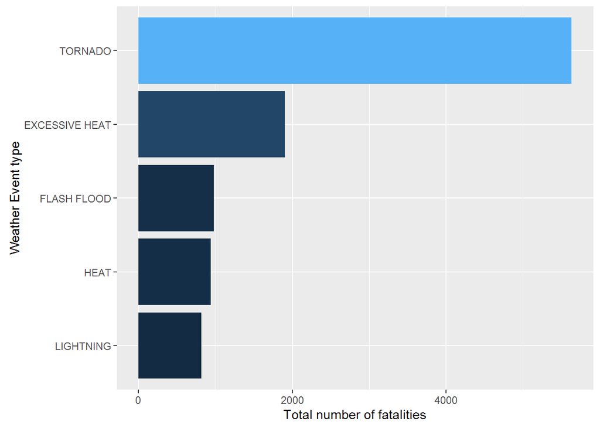

```r
ggplot(data=fatalities_events,
             aes(x=reorder(EVTYPE, fatalities), y=fatalities, fill=fatalities)) +
    geom_bar(stat="identity") +
    coord_flip() +
    ylab("Total number of fatalities") +
    xlab("Weather Event type") +
    theme(legend.position="none")
```

### Plot for Top 5 Severe Weather Events with Highest Injuries

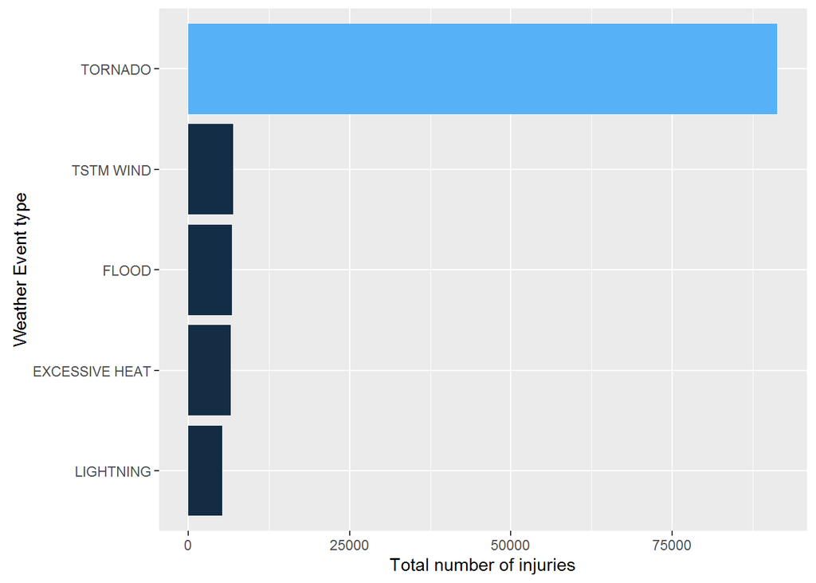

```r
ggplot(data=injuries_events,
             aes(x=reorder(EVTYPE, injuries), y=injuries, fill=injuries)) +
    geom_bar(stat="identity") +
    coord_flip() +
    ylab("Total number of injuries") +
    xlab("Weather Event type") +
    theme(legend.position="none")
```

## Which types of events have the greatest economic consequences?

The PROPDMG and CROPDMG columns in the storm data contain the Property Damage cost and Crop Damage cost respectively. Calculating that will allow us see which weather event types have the most economic consequences.

### Calculating the Property Damage

#### Since the columns PROPDMGEXP and CROPDMGEXP contain the exponent indicator of the values in hundreds (h), thousands (k), millions (m), and billions (B), I am creating a function named GetDMGValue to calculate the real cost for each row based on the value of the PROPDMGEX and CROPDMGEXP.

```r
GetDMGValue<- function(e,val) {
    # h -> hundred, k -> thousand, m -> million, b -> billion
    if (e %in% c('h', 'H'))
        return((10**2) * val)
    else if (e %in% c('k', 'K'))
        return ((10**3) * val)
    else if (e %in% c('m', 'M'))
        return ((10**6) * val)
    else if (e %in% c('b', 'B'))
        return ((10**9) * val)
    else if (!is.na(as.numeric(e))) # if a digit
        return(as.numeric(e))
    else if (e %in% c('', '-', '?', '+'))
        return(0)
    else {
        stop("Invalid exponent value.")
    }
}

stormData$PROGDMGVal<-mapply(GetDMGValue,stormData$PROPDMGEXP,stormData$PROPDMG)
stormData$CROPDMGVal<-mapply(GetDMGValue,stormData$CROPDMGEXP,stormData$CROPDMG)
```

### With the property damage cost and crop cost values added to storm data data frame, I am goin to summarize the cost for each types and sort them to select the top 5 event per categories.

```r
costlyEvents <- stormData[,c("EVTYPE","PROGDMGVal","CROPDMGVal")]

costlyEventsSummarize <- ddply(costlyEvents, .(EVTYPE), summarize,
                    propertyCost = sum(PROGDMGVal),
                    cropCost = sum(CROPDMGVal))

propCostEvents <- head(costlyEventsSummarize[order(costlyEventsSummarize$propertyCost, decreasing = T), ], 5)

cropCostEvents <- head(costlyEventsSummarize[order(costlyEventsSummarize$cropCost, decreasing = T), ],5)
```

### Plot for Top 5 Severe Weather Events with Highest Property Damage

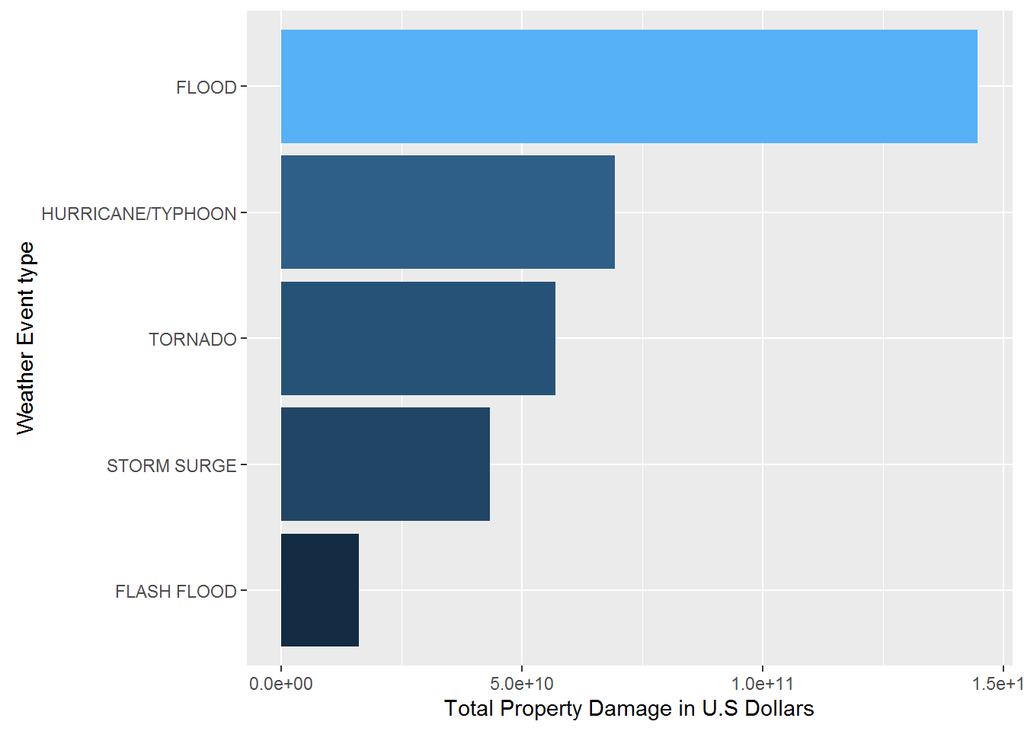

```r
ggplot(data=propCostEvents,
             aes(x=reorder(EVTYPE, propertyCost), y=propertyCost, fill=propertyCost)) +
    geom_bar(stat="identity") +
    coord_flip() +
    ylab("Total Property Damage in U.S Dollars") +
    xlab("Weather Event type") +
    theme(legend.position="none")
```

### Plot for Top 5 Severe Weather Events with Highest Crop Damage

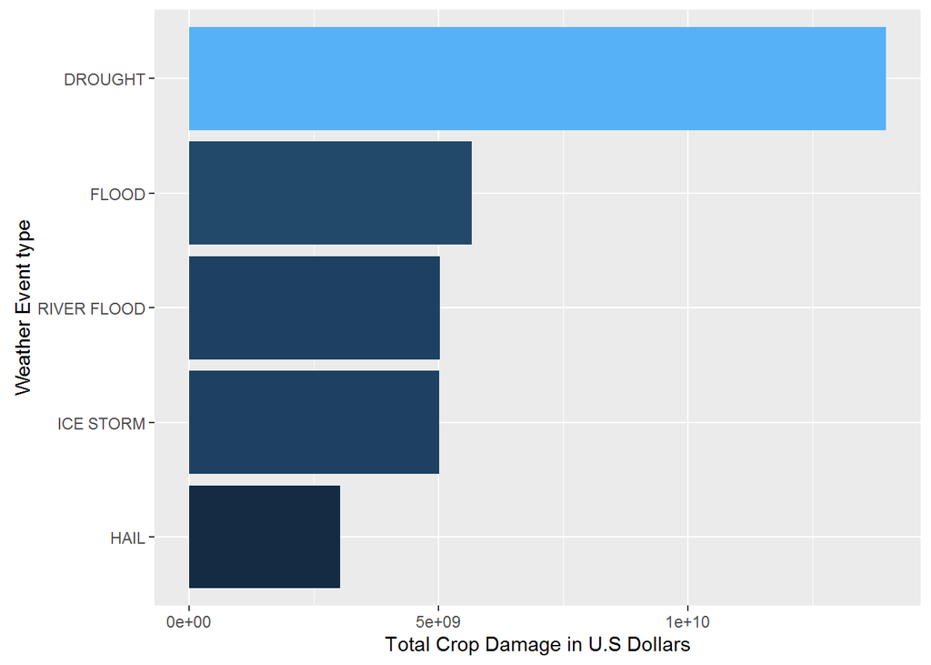

```r
ggplot(data=cropCostEvents,
             aes(x=reorder(EVTYPE, cropCost), y=cropCost, fill=cropCost)) +
    geom_bar(stat="identity") +
    coord_flip() +
    ylab("Total Crop Damage in U.S Dollars") +
    xlab("Weather Event type") +
    theme(legend.position="none")
```